# Heart_project

**P&S Project on Data Analysis and Visualization**

For our project we decided to analyze the dataset from https://www.kaggle.com/fedesoriano/heart-failure-prediction

concerning the heart diseases and health parameters which might be indicators to the health disease

and used further to predict the possibility of a heart disease given these parameters.

We decided to focus on few of the parameters and show how age, cholesterol level and sex might correlates to heart diseases.

```r
library(ggplot2)
library(BSDA)
library(fitdistrplus)
```

### Reading and processing the data

```r
heart <- read.csv("heart.csv")
```

**General information about the data obtained**

```r
summary(heart)
```

```
##       Age            Sex            ChestPainType        RestingBP
##  Min.   :28.00   Length:918         Length:918         Min.   :  0.0
##  1st Qu.:47.00   Class :character   Class :character   1st Qu.:120.0
##  Median :54.00   Mode  :character   Mode  :character   Median :130.0
##  Mean   :53.51                                         Mean   :132.4
##  3rd Qu.:60.00                                         3rd Qu.:140.0
##  Max.   :77.00                                         Max.   :200.0
##   Cholesterol      FastingBS       RestingECG            MaxHR
##  Min.   :  0.0   Min.   :0.0000   Length:918         Min.   : 60.0
##  1st Qu.:173.2   1st Qu.:0.0000   Class :character   1st Qu.:120.0
##  Median :223.0   Median :0.0000   Mode  :character   Median :138.0
##  Mean   :198.8   Mean   :0.2331                      Mean   :136.8
##  3rd Qu.:267.0   3rd Qu.:0.0000                      3rd Qu.:156.0
##  Max.   :603.0   Max.   :1.0000                      Max.   :202.0
##  ExerciseAngina        Oldpeak          ST_Slope          HeartDisease
##  Length:918         Min.   :-2.6000   Length:918         Min.   :0.0000
##  Class :character   1st Qu.: 0.0000   Class :character   1st Qu.:0.0000
##  Mode  :character   Median : 0.6000   Mode  :character   Median :1.0000
##                     Mean   : 0.8874                      Mean   :0.5534
##                     3rd Qu.: 1.5000                      3rd Qu.:1.0000
##                     Max.   : 6.2000                      Max.   :1.0000
```

**Visualizing the correlation between parameters and Heart Failures**

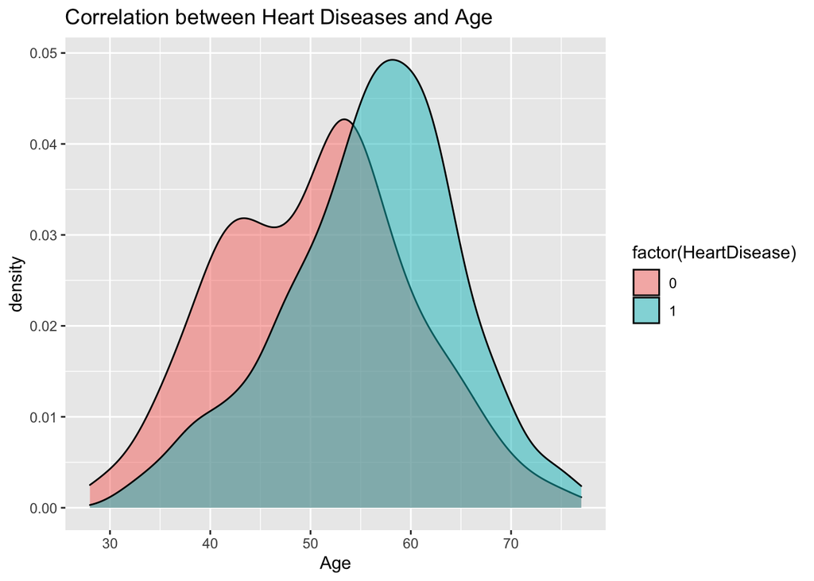

```r
ggplot(heart,aes(x=Age,fill=factor(HeartDisease)))+geom_density(alpha=0.5)+
 xlab(label = "Age")+
 ggtitle("Correlation between Heart Diseases and Age")
```

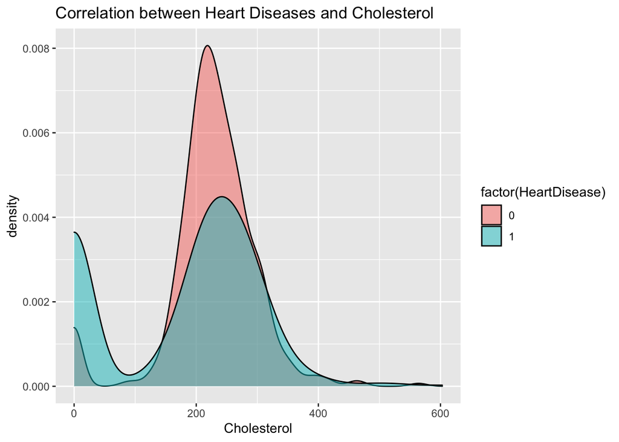

```r
ggplot(heart,aes(x=Cholesterol,fill=factor(HeartDisease)))+geom_density(alpha=0.5)+
 xlab(label = "Cholesterol")+
 ggtitle("Correlation between Heart Diseases and Cholesterol")
```

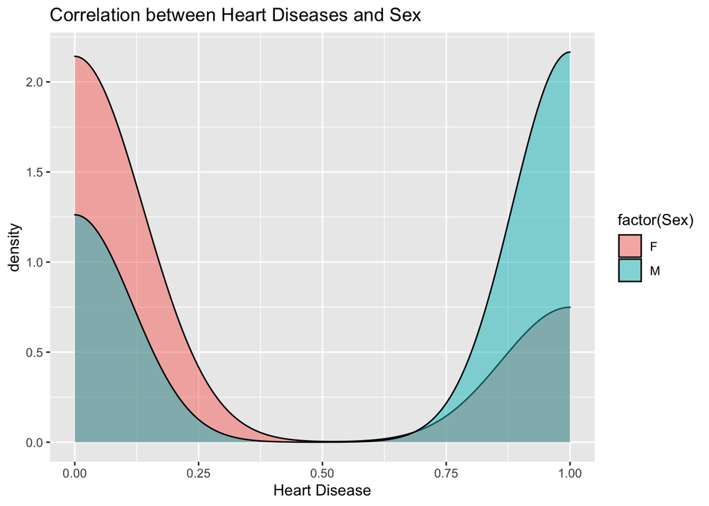

```r
ggplot(heart,aes(x=HeartDisease,fill=factor(Sex)))+geom_density(alpha=0.5)+
 xlab(label = "Heart Disease")+
 ggtitle("Correlation between Heart Diseases and Sex")
```

**However, let’s take a look on the number of males and females**

```r
summary(heart$Sex)
```

```
##    Length     Class      Mode
##       918 character character
```

```r
summary(heart$Sex == "M")
```

```
##    Mode   FALSE    TRUE
## logical     193     725
```

Therefore, there is information about 193 females and 725 males in this dataset.

heart diseases, than males, whose number in the given statistics of the dataset is 3.5 times larger than females’

**Determination of the Age and Cholesterol distributions**

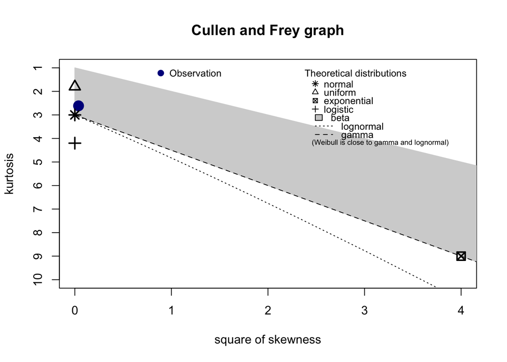

```
## summary statistics
## ------
## min:  28   max:  77
## median:  54
## mean:  53.51089
## estimated sd:  9.432617
## estimated skewness:  -0.195933
## estimated kurtosis:  2.61386
```

```r
descdist(heart$Age)
```

Given these results, we might assume that distribution of the age in the given statistics is close to normal.

Let’s apply this to Cholesterol as well

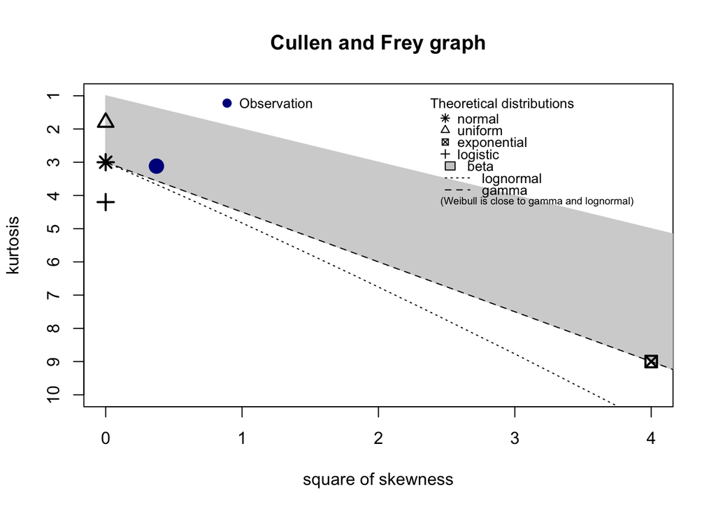

```
## summary statistics
## ------
## min:  0   max:  603
## median:  223
## mean:  198.7996
## estimated sd:  109.3841
## estimated skewness:  -0.6100864
## estimated kurtosis:  3.118208
```

```r
descdist(heart$Cholesterol)
```

Cholesterol distribution is close to normal as well, but it is not that close as Age’s distribution. We’ll see it in a bit.

### Testing

First, let’s visualize the distribution of the Age and Cholesterol (without correlation to heart failure, as we did it before)

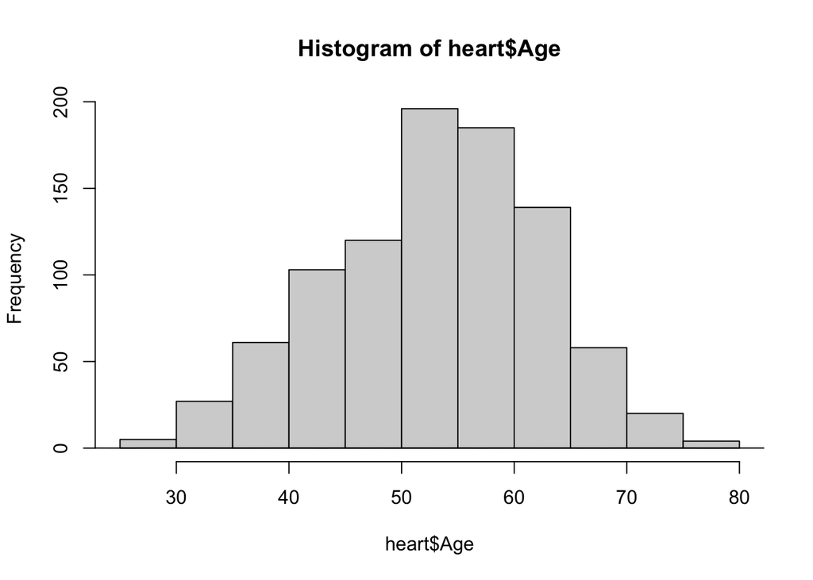

```r
cholesterol <- heart$Cholesterol
cholesterol = cholesterol[cholesterol != 0]
hist(heart$Age)
lines(x=dnorm(heart$Age, mean=mean(heart$Age), sd=sd(heart$Age)))
```

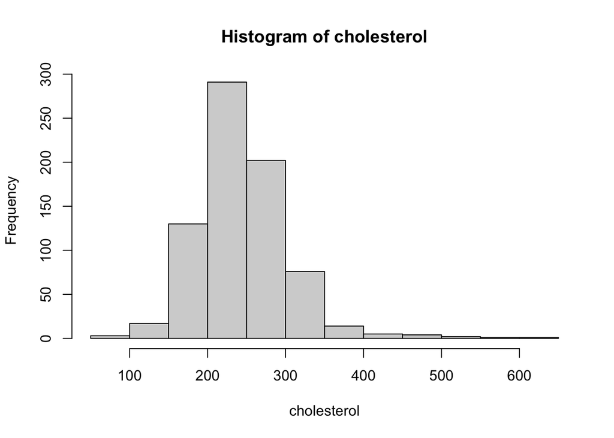

```r
hist(cholesterol)
```

We see that Age and Cholesterol distributions look like normal distributions, though skewed.

Cholesterol distribution is right skewed.

Now, let’s finally test if age or cholesterol data are normally distributed. For this we will use Shapiro-Wilk test for normality.

**Normal distribution**

```r
shapiro.test(heart$Age)
```

```
##
##  Shapiro-Wilk normality test
##
## data:  heart$Age
## W = 0.99101, p-value = 2.165e-05
```

```r
shapiro.test(cholesterol)
```

```
##
##  Shapiro-Wilk normality test
##
## data:  cholesterol
## W = 0.93574, p-value < 2.2e-16
```

As we can see, p-values for both test converge to zero, so neither age nor cholesterol data follow normal distribution, even though p-value

of the Age is a lot bigger than cholesterol’s, which could be seen from the graphics above.

Let’s test it on exponential distribution using Kolmogorov-Smirnov test.

**Exponential distribution**

```r
ks.test(heart$Age, 'pexp', rate=1/mean(heart$Age))
```

```
##
##  One-sample Kolmogorov-Smirnov test
##
## data:  heart$Age
## D = 0.45776, p-value < 2.2e-16
## alternative hypothesis: two-sided
```

```r
ks.test(cholesterol, 'pexp', rate=1/mean(cholesterol))
```

```
##
##  One-sample Kolmogorov-Smirnov test
##
## data:  cholesterol
## D = 0.44654, p-value < 2.2e-16
## alternative hypothesis: two-sided
```

So we see that age and cholesterol doesn’t follow exponential distribuition either.

**Cholesterol and Age**

Now let’s test if Age and Cholesterol level are independent using chi-squared test.

```r
chisq.test(heart$Cholesterol, heart$Age)
```

```
##
##  Pearson's Chi-squared test
##
## data:  heart$Cholesterol and heart$Age
## X-squared = 11886, df = 10829, p-value = 1.624e-12
```

Now let’s test other features concerning the Heart Disease

**Age and Heart Diseases**

And start with correlation between Age and Heart Diseases

```r
chisq.test(heart$Age, heart$HeartDisease)
```

```
##
##  Pearson's Chi-squared test
##
## data:  heart$Age and heart$HeartDisease
## X-squared = 125.37, df = 49, p-value = 1.282e-08
```

p-value goes to zero therefore Heart Diseases depend on the Age of the person.

**Cholesterol and Heart Diseases**

Now the same for Cholesterol

```r
chisq.test(heart$Cholesterol, heart$HeartDisease)
```

```
##
##  Pearson's Chi-squared test
##
## data:  heart$Cholesterol and heart$HeartDisease
## X-squared = 332.19, df = 221, p-value = 1.86e-06
```

p-value is close to zero therefore Heart Diseases depend on the Cholesterol level of the person.

Now let’s find out whether heart diseases depend on the sex of the person

```r
chisq.test(heart$Sex, heart$HeartDisease)
```

```
##
##  Pearson's Chi-squared test with Yates' continuity correction
##
## data:  heart$Sex and heart$HeartDisease
## X-squared = 84.145, df = 1, p-value < 2.2e-16
```

P-value converges to zero which supports the theory that Heart Diseases depend on the sex

### Conclusion

To conclude, we have shown the dependence of Age, Sex and Cholesterol level on the Heart Failure

and shown interesting correlations between them, especially unobvious fact about females having

less heart failures than males, and pretty obvious such that risk of the heart failure increases with the age.

We have learnt how to work with real-life data and apply knowledge obtained during the course

to a real problem. We were lucky that chosen dataset is very clean, without any NaN values and ready to use in

practice. It really helped us to focus on analyzing the dependencies between features and making assumptions about the

distributions of the data. It turned out that real life data rarely follows the ideal patterns of distributions that we learned

but it is easy to approximate them to normal (even if they dont follow it) and work with them pretty easy.